# TP Final - EEA 2021: Modelado Bayesiano en datasets pequeños

Santiago Amena, Sergio Marchio

# Setup

```r
library(glue)

library(tidyverse)
library(tidymodels)
library(GGally)
library(rstan)
library(shinystan)
library(rstanarm)
```

# Análisis exploratorio

```r
tinto <- read.csv("./datos/winequality-red.csv", sep = ";")
```

```r
tinto
```

| fixed.acidity | volatile.acidity | citric.acid | residual.sugar | chlorides | free.sulfur.dioxide | total.sulfur.dioxide | density | pH | sulphates | alcohol | quality |
| --- | --- | --- | --- | --- | --- | --- | --- | --- | --- | --- | --- |
| 7.4 | 0.700 | 0.00 | 1.90 | 0.076 | 11.0 | 34.0 | 0.99780 | 3.51 | 0.56 | 9.400000 | 5 |
| 7.8 | 0.880 | 0.00 | 2.60 | 0.098 | 25.0 | 67.0 | 0.99680 | 3.20 | 0.68 | 9.800000 | 5 |
| 7.8 | 0.760 | 0.04 | 2.30 | 0.092 | 15.0 | 54.0 | 0.99700 | 3.26 | 0.65 | 9.800000 | 5 |
| 11.2 | 0.280 | 0.56 | 1.90 | 0.075 | 17.0 | 60.0 | 0.99800 | 3.16 | 0.58 | 9.800000 | 6 |
| 7.4 | 0.700 | 0.00 | 1.90 | 0.076 | 11.0 | 34.0 | 0.99780 | 3.51 | 0.56 | 9.400000 | 5 |
| 7.4 | 0.660 | 0.00 | 1.80 | 0.075 | 13.0 | 40.0 | 0.99780 | 3.51 | 0.56 | 9.400000 | 5 |
| 7.9 | 0.600 | 0.06 | 1.60 | 0.069 | 15.0 | 59.0 | 0.99640 | 3.30 | 0.46 | 9.400000 | 5 |
| 7.3 | 0.650 | 0.00 | 1.20 | 0.065 | 15.0 | 21.0 | 0.99460 | 3.39 | 0.47 | 10.000000 | 7 |
| 7.8 | 0.580 | 0.02 | 2.00 | 0.073 | 9.0 | 18.0 | 0.99680 | 3.36 | 0.57 | 9.500000 | 7 |
| 7.5 | 0.500 | 0.36 | 6.10 | 0.071 | 17.0 | 102.0 | 0.99780 | 3.35 | 0.80 | 10.500000 | 5 |

[output cut: 1589 more lines]

```r
summary(tinto)
```

```
##  fixed.acidity   volatile.acidity  citric.acid    residual.sugar
##  Min.   : 4.60   Min.   :0.1200   Min.   :0.000   Min.   : 0.900
##  1st Qu.: 7.10   1st Qu.:0.3900   1st Qu.:0.090   1st Qu.: 1.900
##  Median : 7.90   Median :0.5200   Median :0.260   Median : 2.200
##  Mean   : 8.32   Mean   :0.5278   Mean   :0.271   Mean   : 2.539
##  3rd Qu.: 9.20   3rd Qu.:0.6400   3rd Qu.:0.420   3rd Qu.: 2.600
##  Max.   :15.90   Max.   :1.5800   Max.   :1.000   Max.   :15.500
##    chlorides       free.sulfur.dioxide total.sulfur.dioxide    density
##  Min.   :0.01200   Min.   : 1.00       Min.   :  6.00       Min.   :0.9901
##  1st Qu.:0.07000   1st Qu.: 7.00       1st Qu.: 22.00       1st Qu.:0.9956
##  Median :0.07900   Median :14.00       Median : 38.00       Median :0.9968
##  Mean   :0.08747   Mean   :15.87       Mean   : 46.47       Mean   :0.9967
##  3rd Qu.:0.09000   3rd Qu.:21.00       3rd Qu.: 62.00       3rd Qu.:0.9978
##  Max.   :0.61100   Max.   :72.00       Max.   :289.00       Max.   :1.0037
##        pH          sulphates         alcohol         quality
##  Min.   :2.740   Min.   :0.3300   Min.   : 8.40   Min.   :3.000
##  1st Qu.:3.210   1st Qu.:0.5500   1st Qu.: 9.50   1st Qu.:5.000
##  Median :3.310   Median :0.6200   Median :10.20   Median :6.000
##  Mean   :3.311   Mean   :0.6581   Mean   :10.42   Mean   :5.636
##  3rd Qu.:3.400   3rd Qu.:0.7300   3rd Qu.:11.10   3rd Qu.:6.000
##  Max.   :4.010   Max.   :2.0000   Max.   :14.90   Max.   :8.000
```

```r
glimpse(tinto)
```

```
## Rows: 1,599
## Columns: 12
## $ fixed.acidity        <dbl> 7.4, 7.8, 7.8, 11.2, 7.4, 7.4, 7.9, 7.3, 7.8, 7.5~
## $ volatile.acidity     <dbl> 0.700, 0.880, 0.760, 0.280, 0.700, 0.660, 0.600, ~
## $ citric.acid          <dbl> 0.00, 0.00, 0.04, 0.56, 0.00, 0.00, 0.06, 0.00, 0~
## $ residual.sugar       <dbl> 1.9, 2.6, 2.3, 1.9, 1.9, 1.8, 1.6, 1.2, 2.0, 6.1,~
## $ chlorides            <dbl> 0.076, 0.098, 0.092, 0.075, 0.076, 0.075, 0.069, ~
## $ free.sulfur.dioxide  <dbl> 11, 25, 15, 17, 11, 13, 15, 15, 9, 17, 15, 17, 16~
## $ total.sulfur.dioxide <dbl> 34, 67, 54, 60, 34, 40, 59, 21, 18, 102, 65, 102,~
## $ density              <dbl> 0.9978, 0.9968, 0.9970, 0.9980, 0.9978, 0.9978, 0~
## $ pH                   <dbl> 3.51, 3.20, 3.26, 3.16, 3.51, 3.51, 3.30, 3.39, 3~
## $ sulphates            <dbl> 0.56, 0.68, 0.65, 0.58, 0.56, 0.56, 0.46, 0.47, 0~
## $ alcohol              <dbl> 9.4, 9.8, 9.8, 9.8, 9.4, 9.4, 9.4, 10.0, 9.5, 10.~
## $ quality              <int> 5, 5, 5, 6, 5, 5, 5, 7, 7, 5, 5, 5, 5, 5, 5, 5, 7~
```

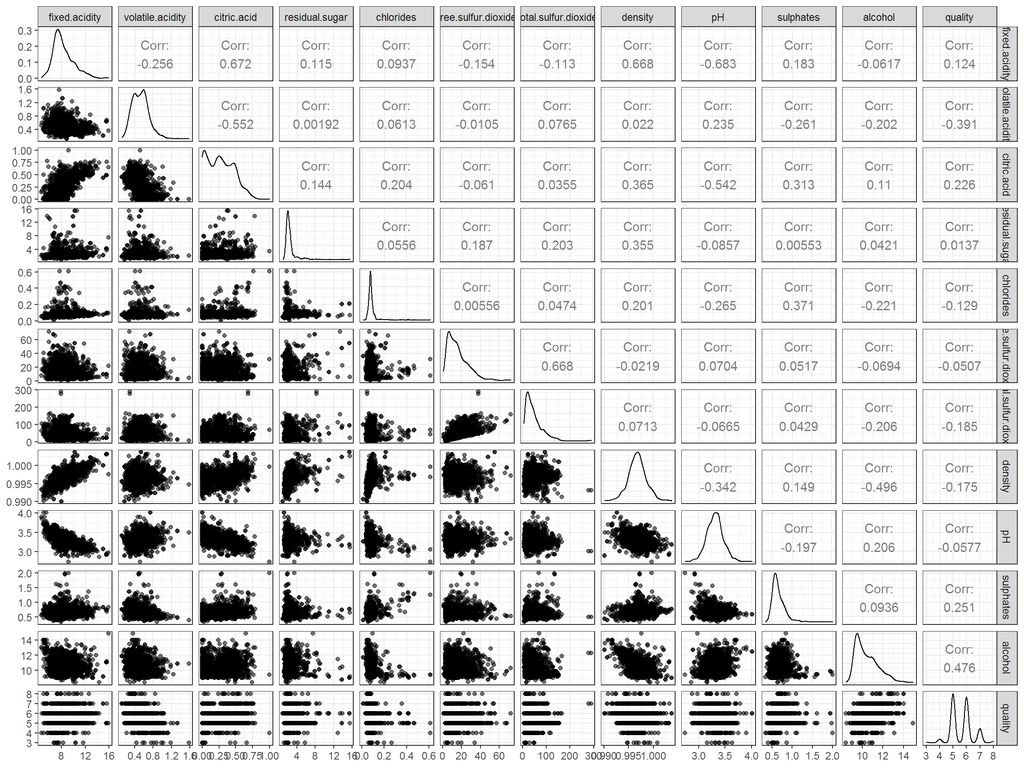

```r
ggpairs(tinto, aes(alpha = 0.5)) + theme_bw()
```

La variable más correlacionada con *quality* es *alcohol*: corr = 0.476

- *quality* es una medida arbitraria de la calidad del vino yendo de 0 (muy malo) a 10 (excelente).
- *alcohol* es la graduación alcohólica medida en porcentaje volumen en volumen (% vol.).

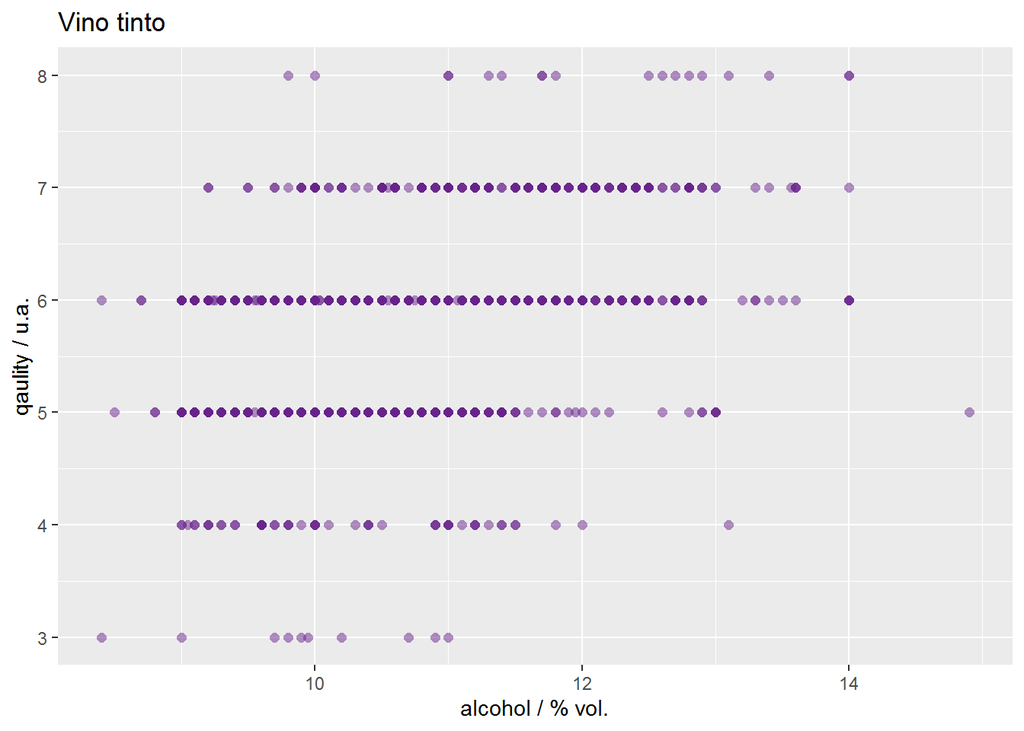

```r
ggplot(tinto, aes(x = alcohol, y = quality)) +
  geom_point(color = "darkorchid4", alpha = 0.5, shape = 16, size = 2) +
  ggtitle("Vino tinto") +
  xlab("alcohol / % vol.") +
  ylab("qaulity / u.a.")
```

Se explora el modelo

$quality = \beta_0 + \beta_1 alcohol + \varepsilon$

```r
ajuste_exploratorio <- lm(quality ~ alcohol, tinto)

summary(ajuste_exploratorio)
```

```
##
## Call:
## lm(formula = quality ~ alcohol, data = tinto)
##
## Residuals:
##     Min      1Q  Median      3Q     Max
## -2.8442 -0.4112 -0.1690  0.5166  2.5888
##
## Coefficients:
##             Estimate Std. Error t value Pr(>|t|)
## (Intercept)  1.87497    0.17471   10.73   <2e-16 ***
## alcohol      0.36084    0.01668   21.64   <2e-16 ***
## ---
## Signif. codes:  0 '***' 0.001 '**' 0.01 '*' 0.05 '.' 0.1 ' ' 1
##
## Residual standard error: 0.7104 on 1597 degrees of freedom
## Multiple R-squared:  0.2267, Adjusted R-squared:  0.2263
## F-statistic: 468.3 on 1 and 1597 DF,  p-value: < 2.2e-16
```

Se grafican los datos junto con el ajuste lineal correspondiente

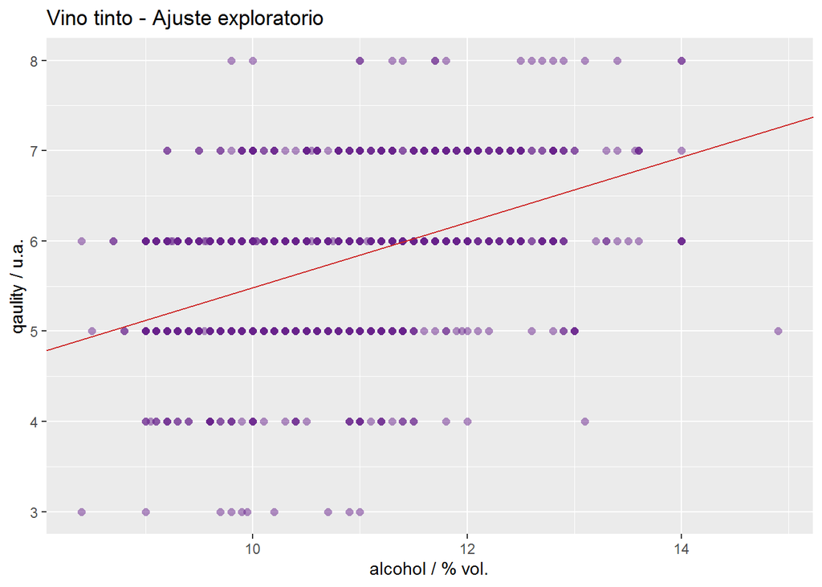

```r
ggplot(tinto, aes(x = alcohol, y = quality)) +
  geom_point(color = "darkorchid4", alpha = 0.5, shape = 16, size = 2) +
  geom_abline(intercept = coef(ajuste_exploratorio)[1],
              slope = coef(ajuste_exploratorio)[2],
              color = "firebrick3") +
  ggtitle("Vino tinto - Ajuste exploratorio") +
  xlab("alcohol / % vol.") +
  ylab("qaulity / u.a.")
```

Se seleccionan las variables a utilizar

```r
datos <- tinto %>%
    select(alcohol, quality)

datos
```

| alcohol | quality |
| --- | --- |
| 9.400000 | 5 |
| 9.800000 | 5 |
| 9.800000 | 5 |
| 9.800000 | 6 |
| 9.400000 | 5 |
| 9.400000 | 5 |
| 9.400000 | 5 |
| 10.000000 | 7 |
| 9.500000 | 7 |
| 10.500000 | 5 |

[output cut: 1589 more lines]

# Diseño experimental

Hay 1599 observaciones.

Se realizan 5 experimentos, donde en cada experimento se toma un tamaño de muestra distinto.

En cada experimento se toman 39 observaciones al azar, sobre las cuales se aplica un modelo linal frecuentista cuyos parámetros son utlizados en las prior del modelo bayesiano optimo, haciendo las veces de “informacion conocida de antes/estudios previos”

Con las restantes 1560 observaciones se hace un cross validation invertido para evaluar la performance de cada metodología

- frecuentista
- bayesiano prior no informativa
- bayesiano prior “optima”

de la siguiente manera:

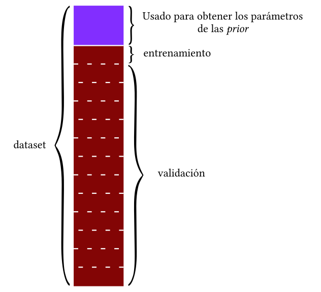

Esquema de partición de los datos para los experimentos.

Se estuidan tamaños de muestra de 6, 12, 24, 40 y 120 observaciones:

- *experimento 1:* 1560/6 = 260 grupos de 6 observaciones
- *experimento 2:* 1560/12 = 130 grupos de 12 observaciones
- *experimento 3:* 1560/24 = 65 grupos de 24 observaciones
- *experimento 4:* 1560/40 = 39 grupos de 40 observaciones
- *experimento 5:* 1560/120 = 13 grupos de 120 observaciones

Lo llamamos *cross validation invertido* ya que el modelo se entrena con un solo *fold* y se evalúa en todos los demás, a diferencia del *cross validation* tradicional, donde se entrena el modelo en $k-1$ *folds* y se evalúa en el restante.

Como medidas de performance se tomarán el $R^2$, $RMSE$ y $MAE$.

```r
# Conjutos de etiquetas para cada set de experimentos.
# la etiqueta '0' corresponde a los datos usados para obtener la prior "optima"
# las etiquetas 1, ..., k corresponden a los subconjuntos para la cross validation

# Numero de observaciones para crear la prior optima
nobs_base <- 39
# Numero de grupos para cada experimento
n_grupos <- c(260, 130, 65, 39, 13)
# Numero total de observaciones
n <- nrow(datos)

grupos <- lapply(n_grupos, FUN = function(x){
    # numero de observaciones por grupo para cada experimento
    nobs <- (n - nobs_base)/x

    # Fija semilla para mantener reproducibilidad
    set.seed(n*x)

    # Devuelve para cada experimento una lista con las etiquetas de grupo ordenadas al azar
    sample(c(rep(0, nobs_base), rep(1:x, nobs)))
})

# Para cada experimento nombra la columna de las etiquetas de grupo como "ex",
# donde x es el numero de experimento
exp <- lapply(1:length(n_grupos), FUN = function(x) paste0("e", x)) %>% unlist()

# se agregan al dataframe las columnas con las etiquetas de grupo para cada experimento
datos[exp] <- grupos

datos
```

| alcohol | quality | e1 | e2 | e3 | e4 | e5 |
| --- | --- | --- | --- | --- | --- | --- |
| 9.400000 | 5 | 40 | 88 | 19 | 39 | 10 |
| 9.800000 | 5 | 131 | 60 | 26 | 14 | 6 |
| 9.800000 | 5 | 200 | 39 | 22 | 5 | 5 |
| 9.800000 | 6 | 141 | 8 | 62 | 8 | 4 |
| 9.400000 | 5 | 82 | 110 | 59 | 21 | 2 |
| 9.400000 | 5 | 214 | 73 | 28 | 20 | 6 |
| 9.400000 | 5 | 197 | 100 | 52 | 9 | 6 |
| 10.000000 | 7 | 243 | 29 | 56 | 39 | 5 |
| 9.500000 | 7 | 143 | 120 | 4 | 13 | 5 |
| 10.500000 | 5 | 242 | 52 | 28 | 13 | 8 |

[output cut: 1589 more lines]

```r
# Funcion para obtener las metricas de una estimacion: R2 adj, rmse, mae
get_metricas <- function(truth, estimate, p = 1){
    r2 <- rsq_vec(truth = truth, estimate = estimate)
    n <- length(truth)
    r2adj <- 1 - (1 - r2)*(n - 1)/(n - p)

    rmse <- rmse_vec(truth = truth, estimate = estimate)
    mae <- mae_vec(truth = truth, estimate = estimate)

    data.frame(rsq_adj = r2adj, rmse = rmse, mae = mae)
}
```

Para cada experimento: * Se calcula la prior optima con un modelo lineal sobre el grupo “0”. * Se entrena en un grupo todos los modelos y se valida en los demás grupos. * Se repite el paso anterior en cada grupo.

```r
# Funcion auxiliar para generar el contenido del archivo .stan dinamicamente
# predefinido para 3 parametros: beta0 ~ normal, beta1 ~ normal, sigma ~ exponential
# los argumentos de la funcion son las prior para el modelo stan.
# sigma_lambda es el parametro de la exponencial: lambda = 1/media
get_stan_code <- function(b0_mu, b0_sigma, b1_mu, b1_sigma, sigma_lambda){
    glue(
    "
    data {
      int<lower=0> N;
      vector[N] x;
      vector[N] y;

      int<lower=0> N_val;
      vector[N_val] x_val;
    }
    parameters {
      real beta0;
      real beta1;
      real<lower=0> sigma;
    }
    model {
      beta0 ~ normal({{b0_mu}}, {{b0_sigma}});
      beta1 ~ normal({{b1_mu}}, {{b1_sigma}});
      sigma ~ exponential({{sigma_lambda}});
      //y ~ normal(beta0 + beta1 * x, sigma);
      y ~ student_t(2, beta0 + beta1 * x, sigma);
    }
    generated quantities {
      //real y_hat [N_val] = normal_rng(beta0 + beta1 * x_val, sigma);
      real y_hat [N_val] = student_t_rng(2, beta0 + beta1 * x_val, sigma);
    }

    ", .open = "{{", .close = "}}"
    )
}
```

## Ejecución

```r
# Archivo para guardar los resultados
archivo_resultados <- "resultados.rds"
if(!file.exists(archivo_resultados)){
    resultados <- data.frame()
} else {
    resultados <- readRDS(archivo_resultados)
}

# Para guardar los tiempos de ejecucion, solamente para tener una noción de lo que tarda el script
archivo_time <- "time.csv"
if(!file.exists(archivo_time)){
    time <- data.frame()
} else {
    time <- read.csv(archivo_time)
    time <- time[, !(names(time) %in% c("X", "d", "unit"))]

    # Corrige clase de la columna con la fecha hora del log
    time$t <- as.POSIXct(time$t)
}


# Se crea el contenido del archivo .stan para el modelo con priors no informativas:
prior_noinfo_stan <- get_stan_code(b0_mu = 0, b0_sigma = 1000,
                                   b1_mu = 0, b1_sigma = 1000,
                                   sigma_lambda = 1 / 100)


# Se realizan todos los experimentos
for (e in exp) {
    time <- rbind(time,
                  data.frame(e = e, grupo = NA, t = Sys.time()))

    # Priors optimas para modelo bayesiano
    priors <- lm(quality ~ alcohol, datos[datos[e] == 0,]) %>% summary()

    # se extraen los estimadores de media y desvio para beta_0
    b0_mu <- priors$coefficients["(Intercept)", "Estimate"]
    b0_sigma <- priors$coefficients["(Intercept)", "Std. Error"]

    # se extraen los estimadores de media y desvio para beta_1
    b1_mu <- priors$coefficients["alcohol", "Estimate"]
    b1_sigma <- priors$coefficients["alcohol", "Std. Error"]

    # se extrae el estimador de la media para sigma
    sigma_mean <- priors$sigma

    # Se crea el contenido del archivo .stan con las prior optimas
    prior_optima_stan <- get_stan_code(b0_mu = b0_mu, b0_sigma = b0_sigma,
                                       b1_mu = b1_mu, b1_sigma = b1_sigma,
                                       sigma_lambda = 1 / sigma_mean)


    # Se obtienen los grupos que todavia no se calcularon para este experimento
    grupos_exp <- unique(datos[datos[e] != 0, e])
    grupos_faltan <- setdiff(grupos_exp, resultados[resultados$exp == e, "grupo"])

    # Para cada grupo se entrenan los modelos en un grupo y se calculan las metricas con los grupos restantes
    for (grupo in grupos_faltan){
        time <- rbind(time,
                      data.frame(e = e, grupo = grupo, t = Sys.time()))

        # Datos de entrenamiento
        datos_grupo <- datos[datos[[e]] == grupo,]
        # Datos de validación
        datos_validacion <- datos[!(datos[[e]] %in% c(0, grupo)), ]

        # Se entrena modelo frecuentista
        frec <- lm(quality ~ alcohol, datos_grupo)
        # Se extraen obtienen los valores predichos
        frec_estimate <- augment(frec, newdata = datos_validacion)$.fitted

        # Se crea data para stan
        dat_stan <- list(N = nrow(datos_grupo),
                         y = datos_grupo$quality,
                         x = datos_grupo$alcohol,
                         N_val = nrow(datos_validacion),
                         x_val = datos_validacion$alcohol)

        # Se entrena modelo bayesiano, priors no informativas
        bayes_noinfo <- stan(model_code = prior_noinfo_stan, data = dat_stan,
                             chains = 3, iter = 1000, warmup = 300, thin = 1)
        # Se extraen los valores predichos de la salida del modelo
        b_noinfo_estimate <- summary(bayes_noinfo)$summary[, "mean"][grepl("^y_hat", names(bayes_noinfo))]

        #Se entrena modelo bayesiano, priors optimas
        bayes_optima <- stan(model_code = prior_optima_stan, data = dat_stan,
                             chains = 3, iter = 1000, warmup = 300, thin = 1)
        # Se extraen los valores predichos de la salida del modelo
        b_optima_estimate <- summary(bayes_optima)$summary[, "mean"][grepl("^y_hat", names(bayes_optima))]

        resultados <- rbind(resultados,
                            cbind(
                                data.frame(exp = e, grupo = grupo, modelo = "frec"),
                                get_metricas(truth = datos_validacion$quality, estimate = frec_estimate)),
                            cbind(
                                data.frame(exp = e, grupo = grupo, modelo = "bayes_noinfo"),
                                get_metricas(truth = datos_validacion$quality, estimate = b_noinfo_estimate)),
                            cbind(
                                data.frame(exp = e, grupo = grupo, modelo = "bayes_optima"),
                                get_metricas(truth = datos_validacion$quality, estimate = b_optima_estimate))
        )

        # Se guarda el avance del experimento
        saveRDS(resultados, file = archivo_resultados)

        write.csv(time %>% mutate(d = t - lag(t),
                                  unit = units.difftime(d)), archivo_time)
    }

}
```

# Resultados

```r
resultados
```

| exp | grupo | modelo | rsq_adj | rmse | mae |
| --- | --- | --- | --- | --- | --- |
| e1 | 40 | frec | 0.2286514252 | 1.8678766 | 1.3891170 |
| e1 | 40 | bayes_noinfo | 0.2245325331 | 1.8871207 | 1.4019667 |
| e1 | 40 | bayes_optima | 0.2190787310 | 0.9345917 | 0.7518851 |
| e1 | 131 | frec | 0.2276749589 | 0.7674460 | 0.5742891 |
| e1 | 131 | bayes_noinfo | 0.2113575713 | 0.7978616 | 0.5979258 |
| e1 | 131 | bayes_optima | 0.2184095856 | 0.7301714 | 0.5555155 |
| e1 | 200 | frec | 0.2240667889 | 1.0282371 | 0.7303732 |
| e1 | 200 | bayes_noinfo | 0.1628496000 | 1.0282207 | 0.7303674 |
| e1 | 200 | bayes_optima | 0.2250700013 | 0.7679483 | 0.5713860 |
| e1 | 141 | frec | 0.2284144831 | 1.0582561 | 0.8642622 |

[output cut: 1511 more lines]

Se crea columna con el tamaño de muestra para mayor claridad en los gráficos

```r
# Se relacionan los nombres de los experimentos con el tamaño de la muestra
niveles_muestra <- c("6" = "e1", "12" = "e2", "24" = "e3", "40" = "e4", "120" = "e5")

# Se crea la nueva variable
resultados <- resultados %>%
    mutate(tam = fct_recode(exp, !!!niveles_muestra))

resultados
```

| exp | grupo | modelo | rsq_adj | rmse | mae | tam |
| --- | --- | --- | --- | --- | --- | --- |
| e1 | 40 | frec | 0.2286514252 | 1.8678766 | 1.3891170 | 6 |
| e1 | 40 | bayes_noinfo | 0.2245325331 | 1.8871207 | 1.4019667 | 6 |
| e1 | 40 | bayes_optima | 0.2190787310 | 0.9345917 | 0.7518851 | 6 |
| e1 | 131 | frec | 0.2276749589 | 0.7674460 | 0.5742891 | 6 |
| e1 | 131 | bayes_noinfo | 0.2113575713 | 0.7978616 | 0.5979258 | 6 |
| e1 | 131 | bayes_optima | 0.2184095856 | 0.7301714 | 0.5555155 | 6 |
| e1 | 200 | frec | 0.2240667889 | 1.0282371 | 0.7303732 | 6 |
| e1 | 200 | bayes_noinfo | 0.1628496000 | 1.0282207 | 0.7303674 | 6 |
| e1 | 200 | bayes_optima | 0.2250700013 | 0.7679483 | 0.5713860 | 6 |
| e1 | 141 | frec | 0.2284144831 | 1.0582561 | 0.8642622 | 6 |

[output cut: 1511 more lines]

```r
# función para graficar boxplot por grupos
boxplot_facet <- function(datos, x, y, grupo, titulo = "", xlab = "", ylab = ""){
    # Se asigna la etiqueta al nombre de la variable si no fue configurada
    if(xlab == "") xlab = as.name(x)
    if(ylab == "") ylab = as.name(y)

    ggplot(datos, aes(x = !!as.name(x), y = !!as.name(y))) +
        geom_boxplot() +
        facet_wrap(grupo) +
        ggtitle(titulo) +
        xlab(xlab) +
        ylab(ylab) +
        theme(strip.background = element_rect(fill = "rosybrown2"))
}
```

Variación de las métricas con el tamaño de muestra para cada modelo:

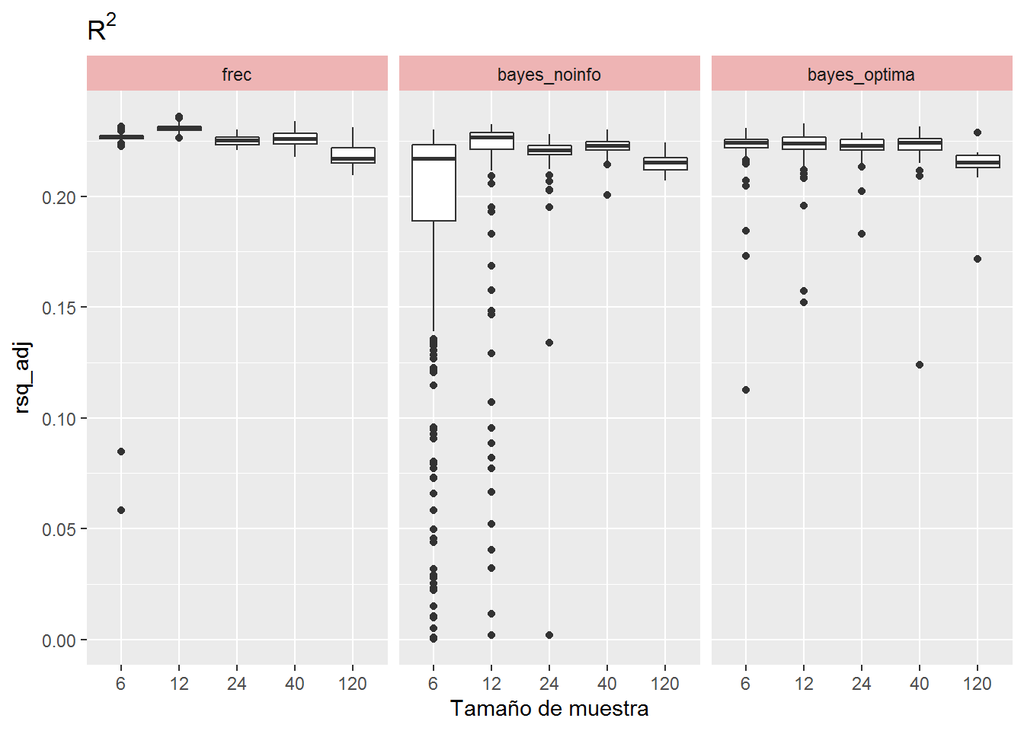

```r
boxplot_facet(resultados, x = "tam", y = "rsq_adj", grupo = "modelo",
              titulo = bquote(R^2), xlab = "Tamaño de muestra")
```

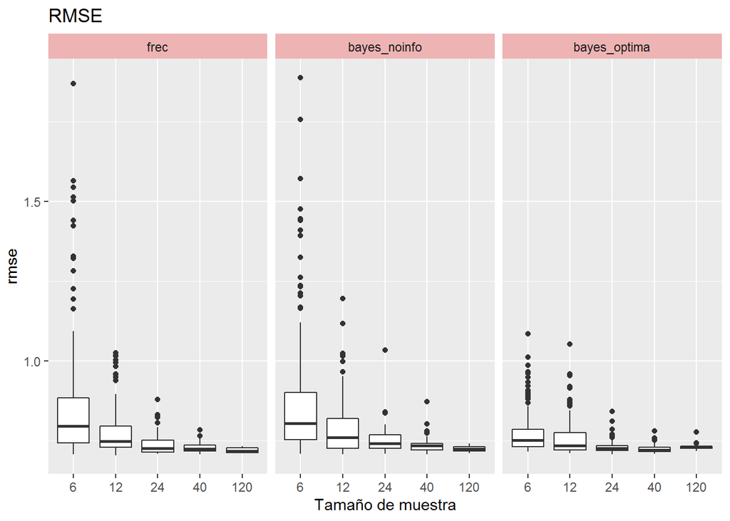

```r
boxplot_facet(resultados, x = "tam", y = "rmse", grupo = "modelo",
              titulo = "RMSE", xlab = "Tamaño de muestra")
```

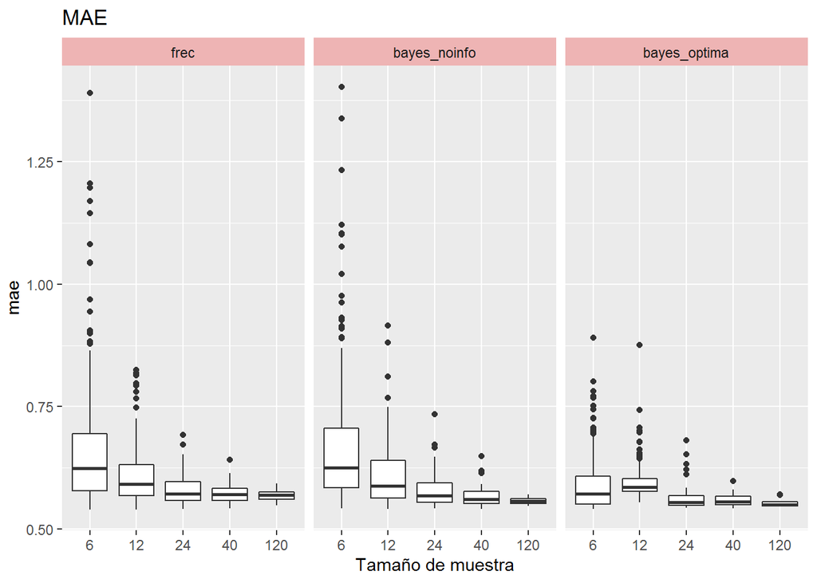

```r
boxplot_facet(resultados, x = "tam", y = "mae", grupo = "modelo",
              titulo = "MAE", xlab = "Tamaño de muestra")
```

Variación de las métricas con el modelo para cada tamaño de muestra:

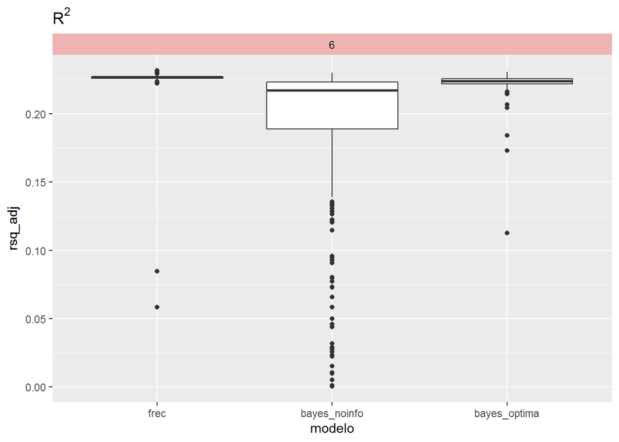

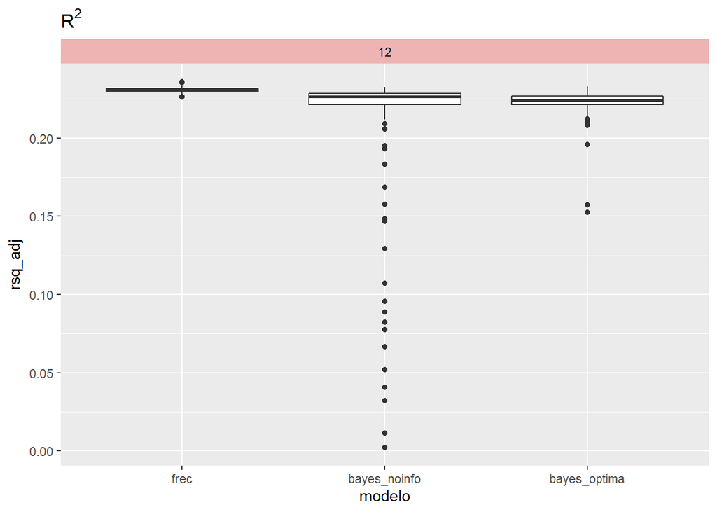

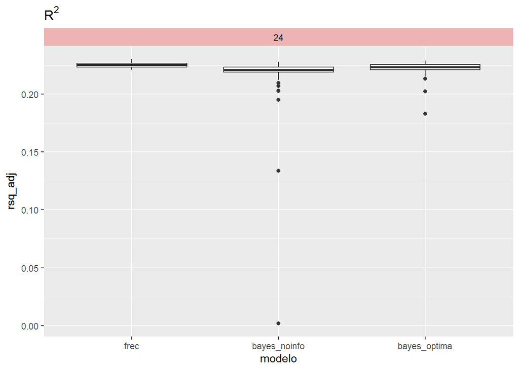

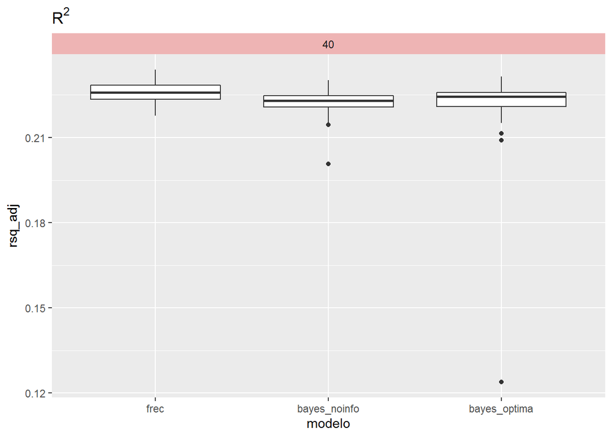

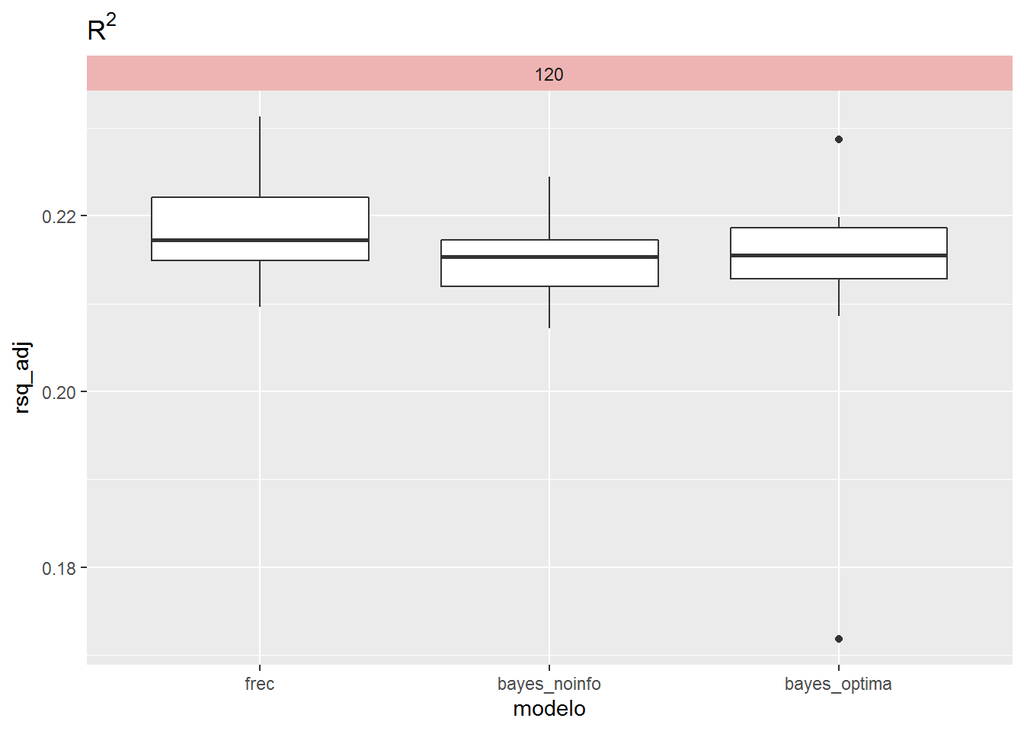

```r
for(t in unique(resultados$tam)){
    plot <- resultados %>%
        filter(tam == t) %>%
        boxplot_facet(x = "modelo", y = "rsq_adj", grupo = "tam",
                      titulo = bquote(R^2))

    print(plot)
}
```

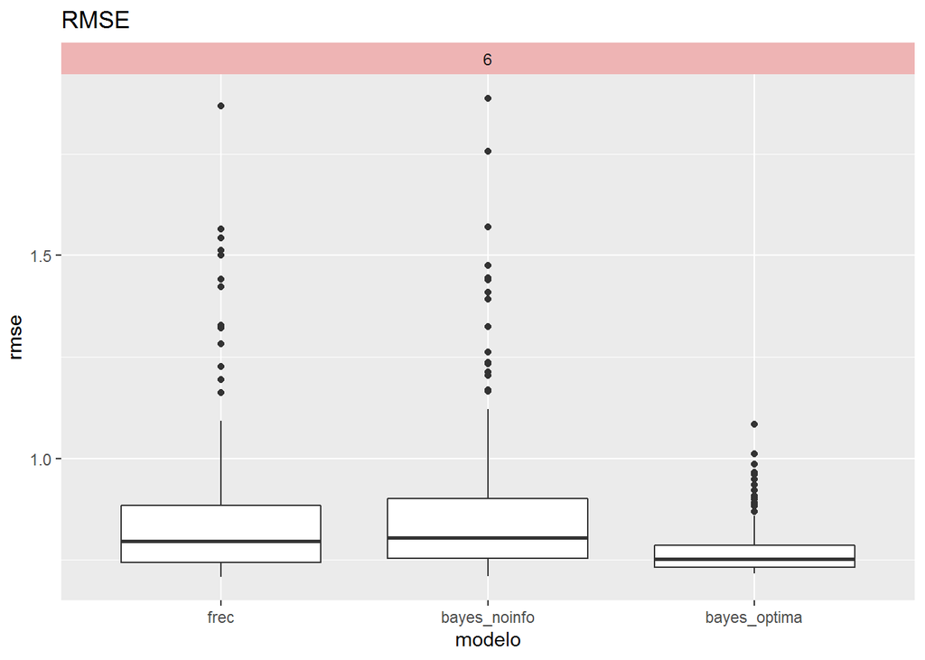

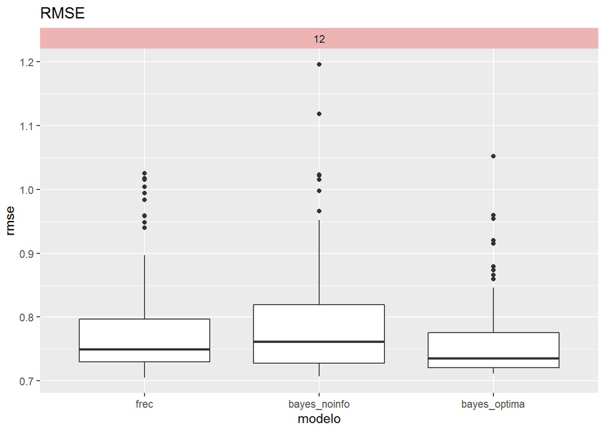

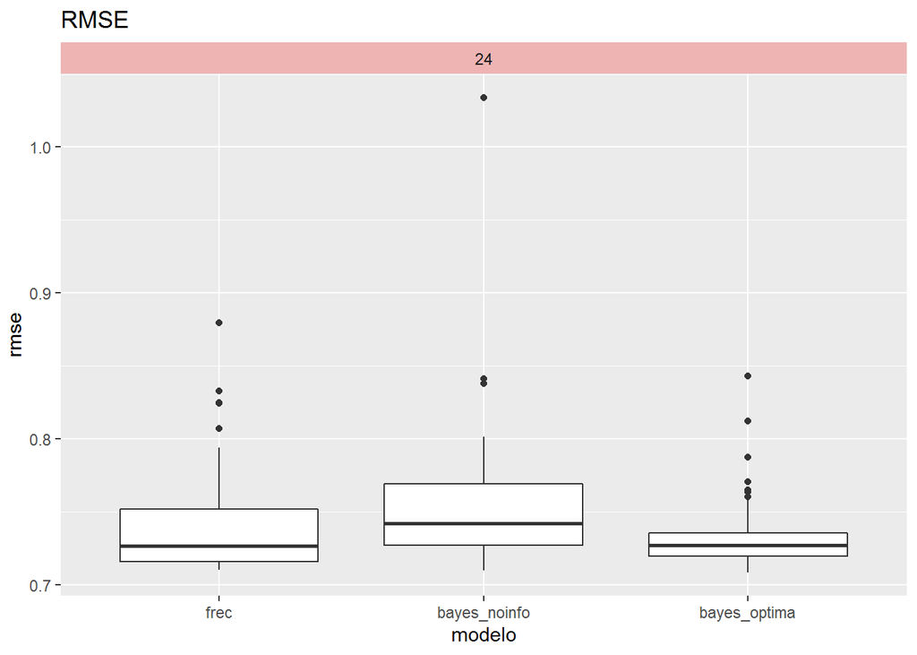

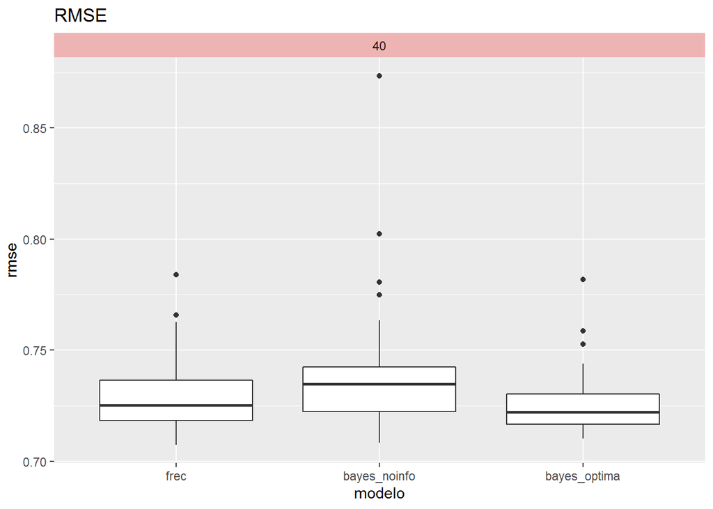

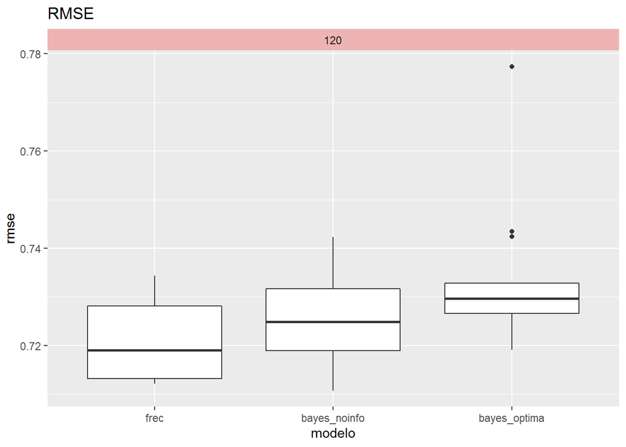

```r
for(t in unique(resultados$tam)){
    plot <- resultados %>%
        filter(tam == t) %>%
        boxplot_facet(x = "modelo", y = "rmse", grupo = "tam",
                      titulo = "RMSE")

    print(plot)
}
```

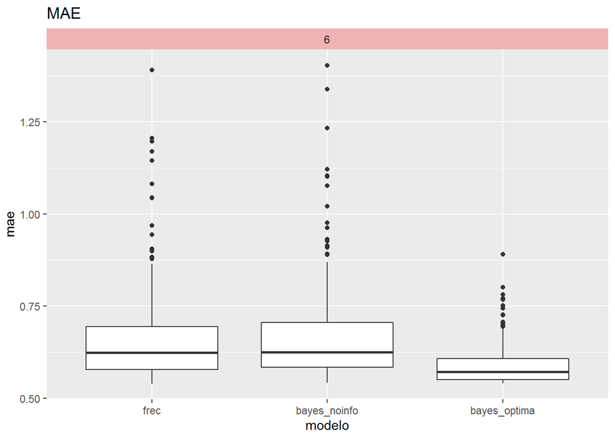

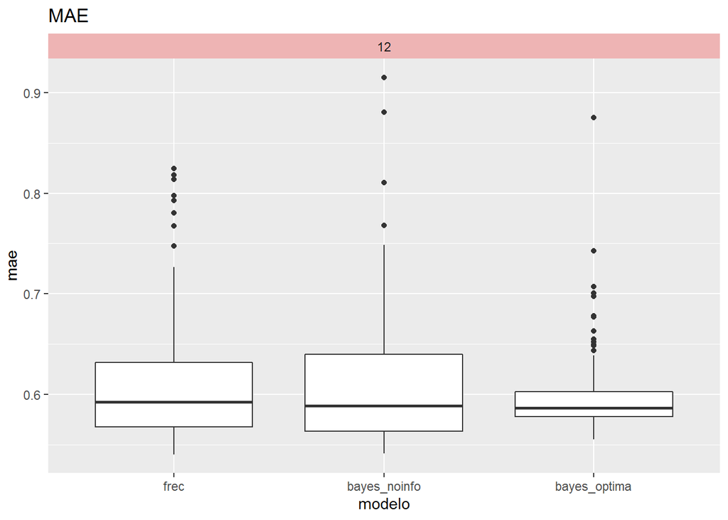

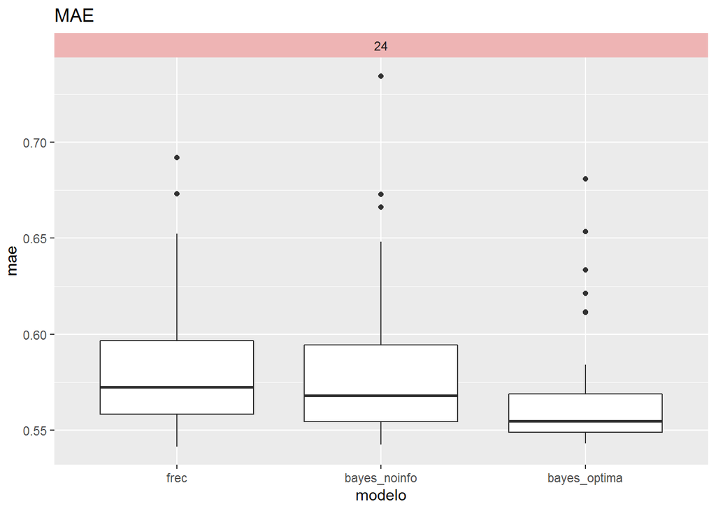

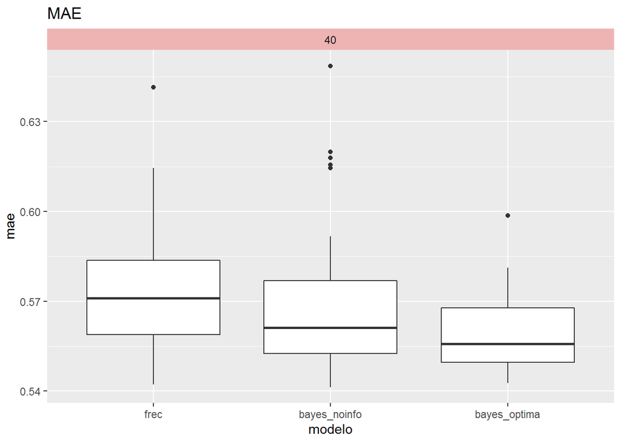

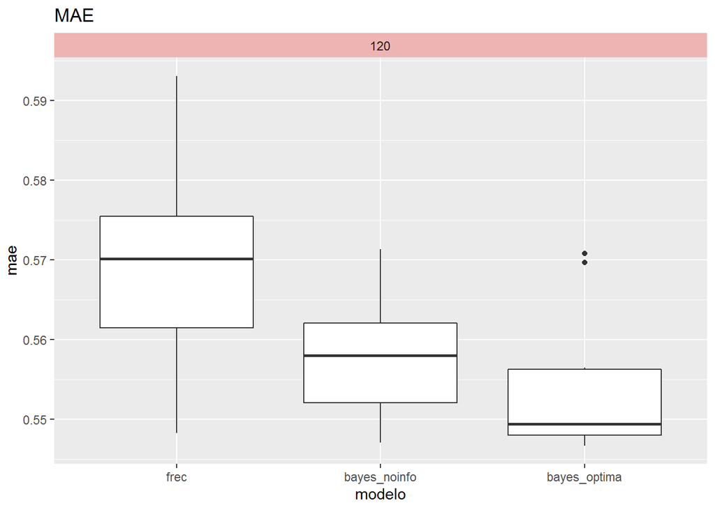

```r
for(t in unique(resultados$tam)){
    plot <- resultados %>%
        filter(tam == t) %>%
        boxplot_facet(x = "modelo", y = "mae", grupo = "tam",
                      titulo = "MAE")

    print(plot)
}
```